# Data driven consensus mapping for the immune atlas

Authors

Affiliations

[Dharmesh D. Bhuva](https://bhuvad.github.io/)

SAiGENCI, The University of Adelaide

South Australian Health and Medical Research Institute (SAHMRI)

Walter and Eliza Hall Institute

Stefano Mangiola

SAiGENCI, The University of Adelaide

Walter and Eliza Hall Institute

Published

October 30, 2024

Abstract

Power analysis

# Load data

Cell types mapping from each method to our consensus dictionary.

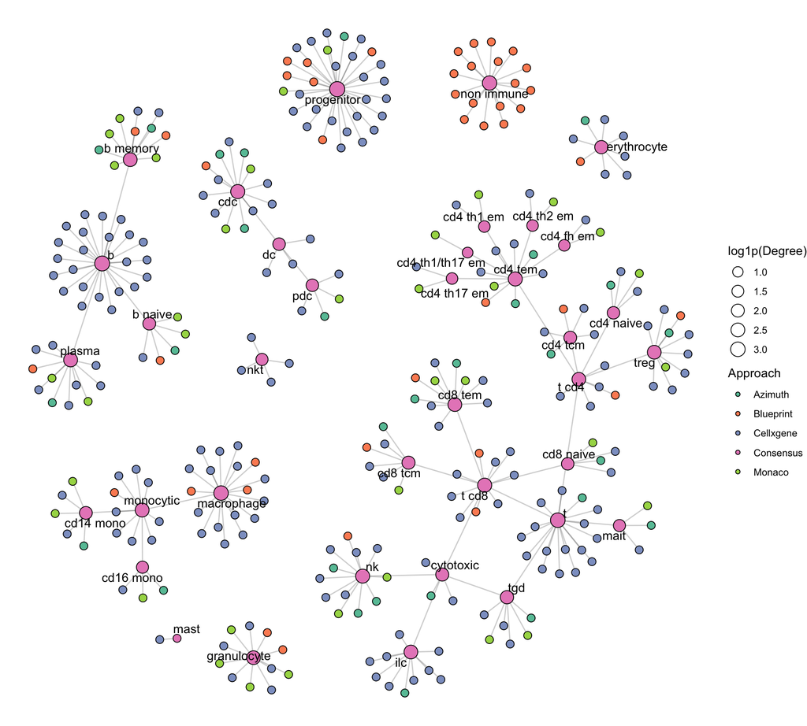

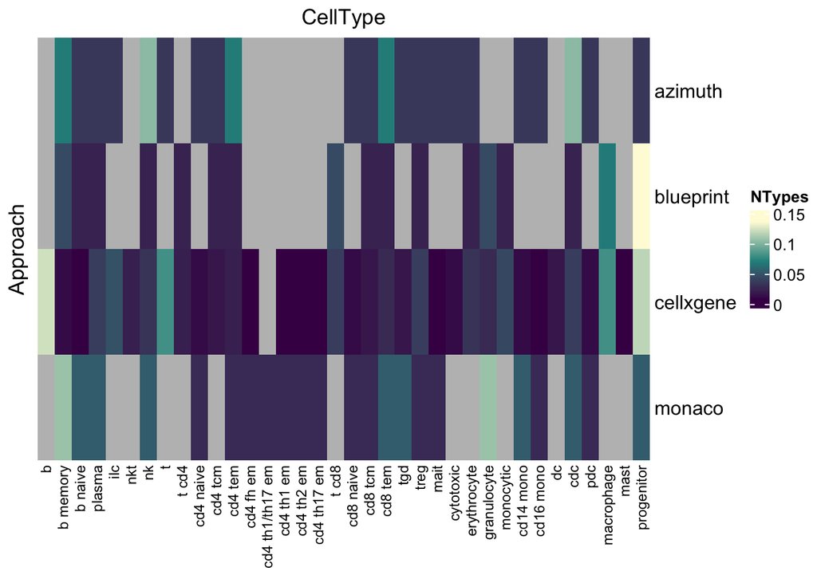

# Explore similarity across approaches

Number of cells captured in each cell type class by the different methods.

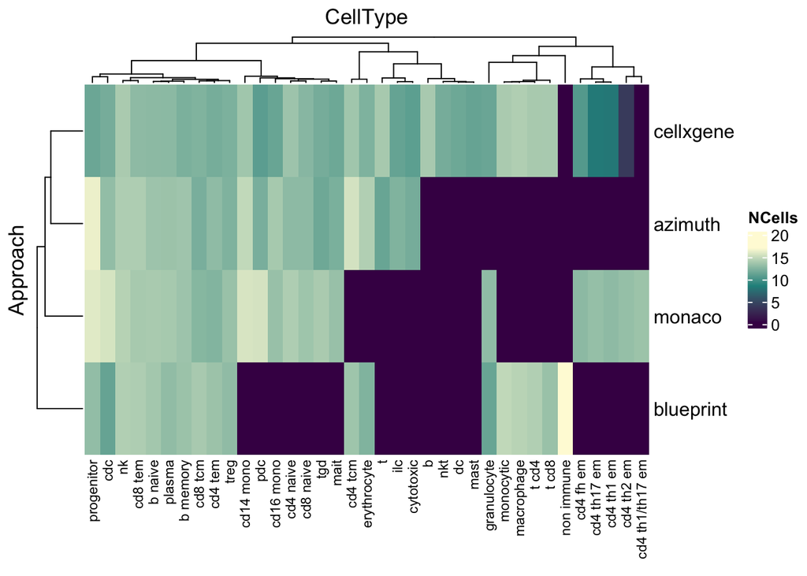

Over/under representation of cell type calling by each method using the following approach where O and E are the observed and expected log cell counts. Negative values mean that we are observing much fewer cells of this type than expected.

$$z=\frac{O-E}{\sqrt{E}}$$

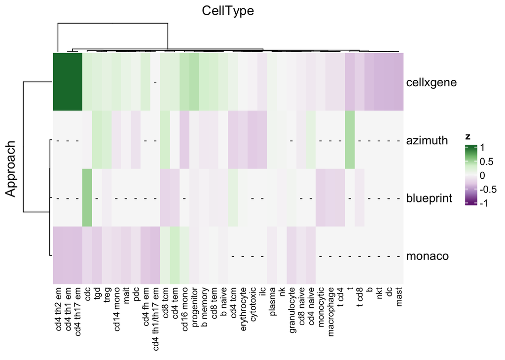

# Map annotations

Two strategies are implemented here. Given a knowledge graph, the idea is to identify the lowest leaf node possible where agreement exisits across prediction approaches. When there is disagreement, the lowest common ancestor where agreement is “highest” is selected. This is done through a vote propagation approach as follows:

1. Each approach get to vote for a cell type where the vote can be weighted as follows:
   1. Equal across approaches.
   2. Weights based on the approach’s overall confidence (high weights for well performing methods).
   3. Weights based on the prediction confidence of each approach (high weights for confident predictions).
   4. A cell type specific weight based on the difficulty in discerning the cell type in general (low weights for cell types that are difficult to discern).
   5. A combination of the previous weighting strategies to incorporate the methods confidence in its cell type call, and the performance of the method in general. The calculation simply requires the cell type vector and weights vector (regardless of how it is derived).
2. The vote for each method is overlayed on the tree, and propagated all the way down to the leaf nodes in that tree.
3. If a unique cell type exists with the highest vote, that is the consensus.
4. If multiple cell types tie on the highest vote, a consensus ancestor algorithm is used to identify the lowest common ancestor.
5. If a consensus ancestor does not exist (or there are ties in the ancestor calls), the cell remains unclassified (NA).

Two stratefies are used to identify the consensus ancestor:

1. Using the graph structure to identify the lowest common ancestor to all cell type predictions (e.g., “t”, when the methods predict “t cd8”, “cd4 fh em”, “tgd”). Here we call this the “conservative” approach as the ancestor has to link to all predicted nodes.
2. Using a weighted vote-based algorithm that now propagates votes from nodes to their parents and ancestors.

The vote-based consensus ancestor algorithm works as follows:

1. Each predicted node shares their vote with their parent. As the vote propagates, it is halved. As such, if one of the predicted nodes is “cd4 th1 em”, and it has a weight of 2, “cd4 tem” gets a vote of 1, “t cd4” gets 0.5 and “t” gets 0.25. Since the node “cd4 th1 em” it self is stricly a leaf node (has incoming edges and no outgoing), it gets a vote of 0 as it cannot be a common ancestor. When the node is not a leaf node (e.g., one of the methods calling this same cell a “t cd4”), the node can vote for it self being the ancestor, however, the vote is not cast as is but gets down-weighted slightly (0.9 in this case). This is to ensure that the common ancestor is found and we are not stuck in the prediction.
2. If a unique cell type exists with the highest vote, that is the consensus ancestor and subsequently the consensus cell type as well.
3. If multiple cell types tie on the highest vote, the cell remains unclassified (NA).

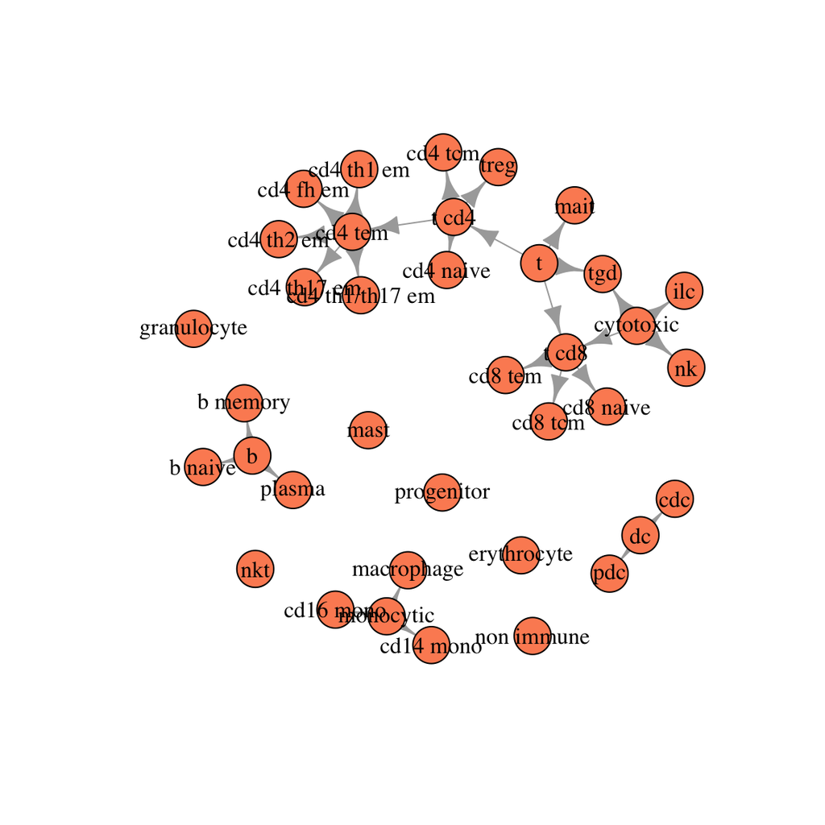

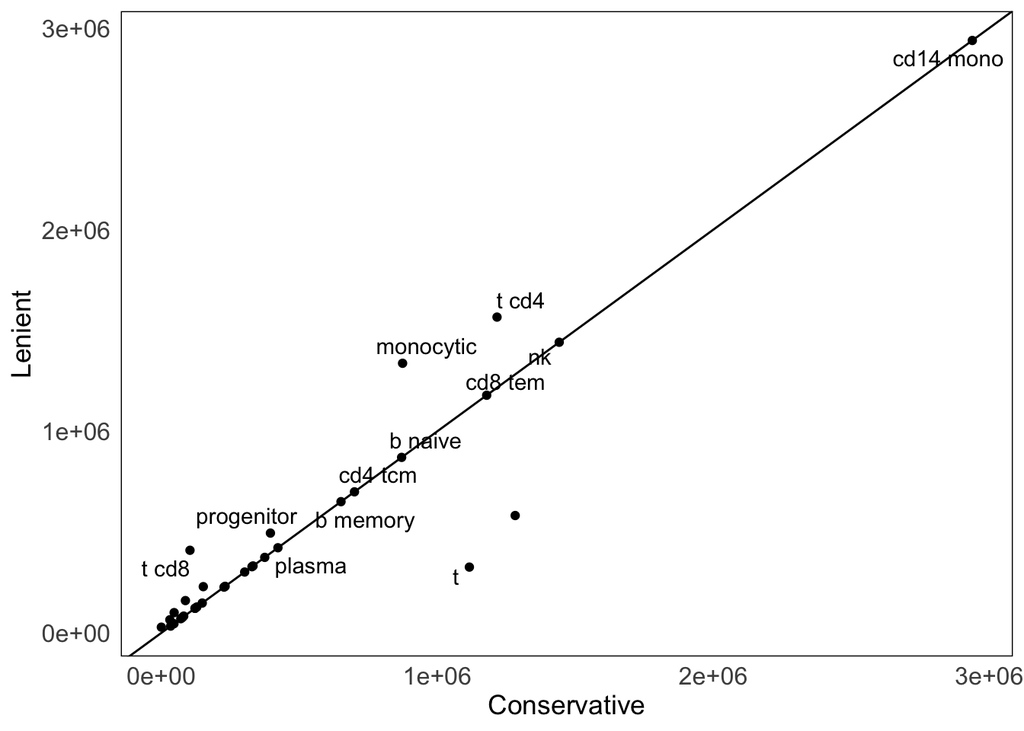